# Comparing workflows of the bsts and the CausalImpact R package

## Introduction

This notebook contains some experiments about fitting Bayesian structural time series using

1. the bsts R package (https://CRAN.R-project.org/package=bsts by Steven L. Scott) and
2. the CausalImpact R package (CausalImpact 1.2.1, Brodersen et al., Annals of Applied Statistics (2015), http://google.github.io/CausalImpact/) which builds on bsts and enables the analysis of the causal impact of an intervention on a time series.

The goal of this notebook is to compare workflows and results, not to achieve the best fit possible. I am fitting one model with a local level and a seasonality component, these components can easily be included into the CausalImpact workflow, using default parameters. In addition, I test a model with an autoregressive and a seasonality component, therefore I need to feed a custom bsts model into CausalImpact. This was a learning exercise I did - maybe it is useful to others. Comments and corrections are welcome.

## Data preparation

As a test data set I am using the “Minimum Daily Temperatures Dataset” which describes the minimum daily temperatures in Melbourne over 10 years. The source of the data is credited as the Australian Bureau of Meteorology. The data set and further explanations can be found here: https://machinelearningmastery.com/time-series-datasets-for-machine-learning/.

For the following experiments roughly the first three years (1096 data points) have been used for training (pre-period), trying to forecast the rest of the time series (post-period, data points 1097 to 3650). For the CausalImpact package this means that I am trying to analyze the causal effect on the target time series due to an intervention that happened after three years. As (to my knowledge) such an intervention did not happen any deviations from the fit in the post-period indicate that the fitted model is not fully capturing the data generating process.

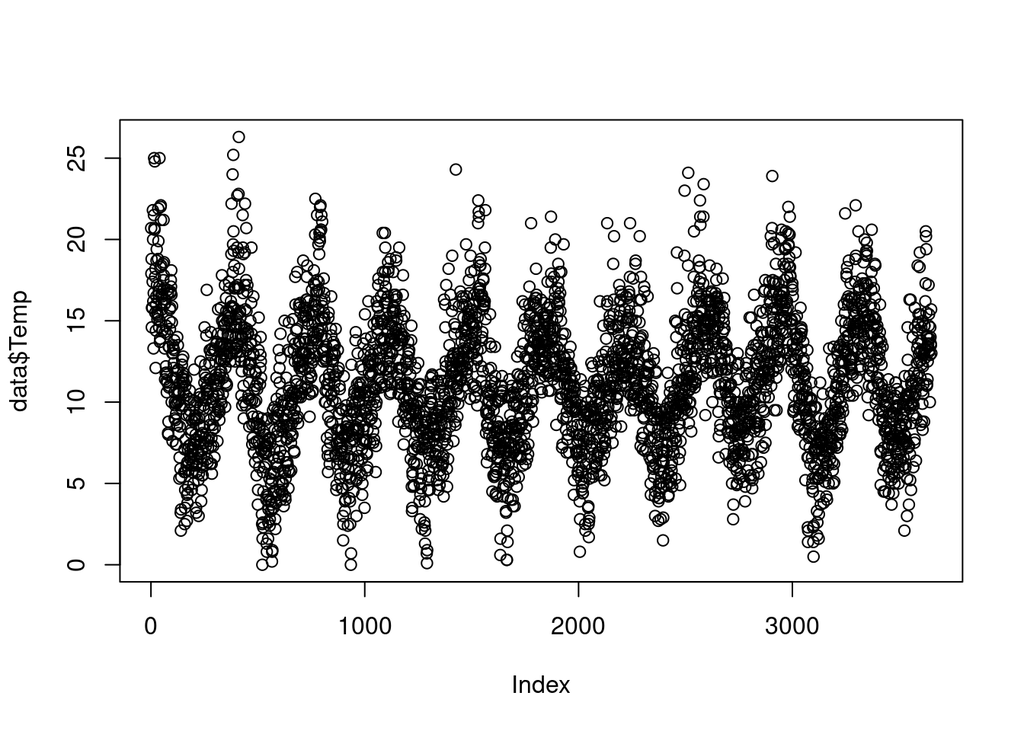

```r
data <- read.csv('daily-min-temperatures.csv')
# plot complete data set
plot(data$Temp)
```

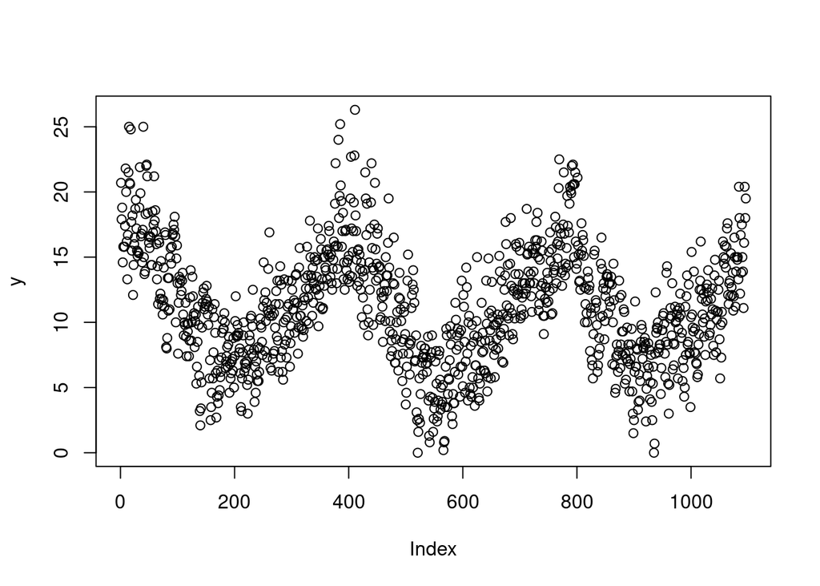

```r
# select roughly the first three years for training
pre.period <- c(1, 1096)
post.period <- c(1097, 3650)
# store training period data in y
y <- data$Temp[1:pre.period[2]]
plot(y)
```

To enable fitting custom models with CausalImpact I need a version of the training data where the post-period entries have been set to NA (see documentation: https://google.github.io/CausalImpact/CausalImpact.html). y contains the pre-period data. y2 holds the same (pre-period) data as y, but still has the post-period entries, where the values have been set to NA.

```r
y2 <- data$Temp
# store post-period data
post.period.response <- data$Temp[(post.period[1]) : post.period[2]]
# target values need to be set to NA in the post period to enable fitting custom models with CausalImpact
y2[post.period[1] : post.period[2]] <- NA
```

The CausalImpact package comes with the the option to standardize the columns of the data set (based on the data from the pre-intervention period) which defaults to true (standardize.data=TRUE). Here, to simplify the comparison with the bsts results, and as discussed in Brodersen et al., I will use the original (unscaled) version of the data and perform the scaling in the priors to ensure a reasonable scale.

```r
# standard deviation of the training data, used for scaling of priors (see variable sdy below)
sd(y)
```

```
## [1] 4.462821
```

## Fit using a random walk and a seasonality component

The random walk (local level) and the seasonality component are both build into the CausalImpact package, hence defaults can be used. For the priors I use the defaults from the CausalImpact package to enable an easy comparison (for details see Brodersen et al. or the CausalImpact object created in R). Also, for the temperature data set used here, the CausalImpact defaults work better than the bsts defaults (side note: with the bsts default priors the local level component picks up some seasonality. As the local level component cannot forecast any seasonality the quality of the fit isn’t good.) For the seasonality component I am using 12 seasons with 31 data points (as the data set has daily temperatures). This will cause some inaccuracies in the long-term forecast as some months have less than 31 days.

Fit the model using bsts:

```r
sdy <- 4.46 # standard deviation of training period

# local level component ... priors adapted from CausalImpact
mu.ll <- zoo(1)
ss.ll.season <- AddLocalLevel(list(),
                              y,
                              sigma.prior = SdPrior(sdy/100,
                                                    sample.size = 32,
                                                    initial.value = sdy/100,
                                                    fixed = FALSE,
                                                    upper.limit = sdy),
                              initial.state.prior = NormalPrior(mu = mu.ll,
                                                                sigma = sdy,
                                                                initial.value = mu.ll,
                                                                fixed = FALSE
                                                                )
                              )

# seasonality component ... priors adapted from CausalImpact
mu.season <- 0
ss.ll.season <- AddSeasonal(ss.ll.season,
                            y,
                            sigma.prior = SdPrior(sdy/100,
                                                  sample.size = 0.01,
                                                  initial.value = sdy/100,
                                                  fixed = FALSE,
                                                  upper.limit = sdy
                                                  ),
                            initial.state.prior = NormalPrior(mu.season,
                                                              sigma = sdy,
                                                              initial.value = mu.season,
                                                              fixed = FALSE
                                                              ),
                            nseasons = 12,
                            season.duration = 31)

# fit the bsts model using 1000 iterations
# the prior here is for the residual noise in the observation equation
model.ll.season <- bsts(y,
                        state.specification = ss.ll.season,
                        family = c("gaussian"),
                        prior = SdPrior(sd(y),
                                        sample.size = 0.01,
                                        initial.value = sdy,
                                        fixed = FALSE,
                                        upper.limit = 1.2 * sdy
                                        ),
                        niter = 1000)
```

```
## =-=-=-=-= Iteration 0 Thu Mar 31 22:03:48 2022 =-=-=-=-=
## =-=-=-=-= Iteration 100 Thu Mar 31 22:03:49 2022 =-=-=-=-=
## =-=-=-=-= Iteration 200 Thu Mar 31 22:03:50 2022 =-=-=-=-=
## =-=-=-=-= Iteration 300 Thu Mar 31 22:03:51 2022 =-=-=-=-=
## =-=-=-=-= Iteration 400 Thu Mar 31 22:03:53 2022 =-=-=-=-=
## =-=-=-=-= Iteration 500 Thu Mar 31 22:03:54 2022 =-=-=-=-=
## =-=-=-=-= Iteration 600 Thu Mar 31 22:03:55 2022 =-=-=-=-=
## =-=-=-=-= Iteration 700 Thu Mar 31 22:03:57 2022 =-=-=-=-=
## =-=-=-=-= Iteration 800 Thu Mar 31 22:03:58 2022 =-=-=-=-=
## =-=-=-=-= Iteration 900 Thu Mar 31 22:03:59 2022 =-=-=-=-=
```

Same fit but via the CausalImpact package:

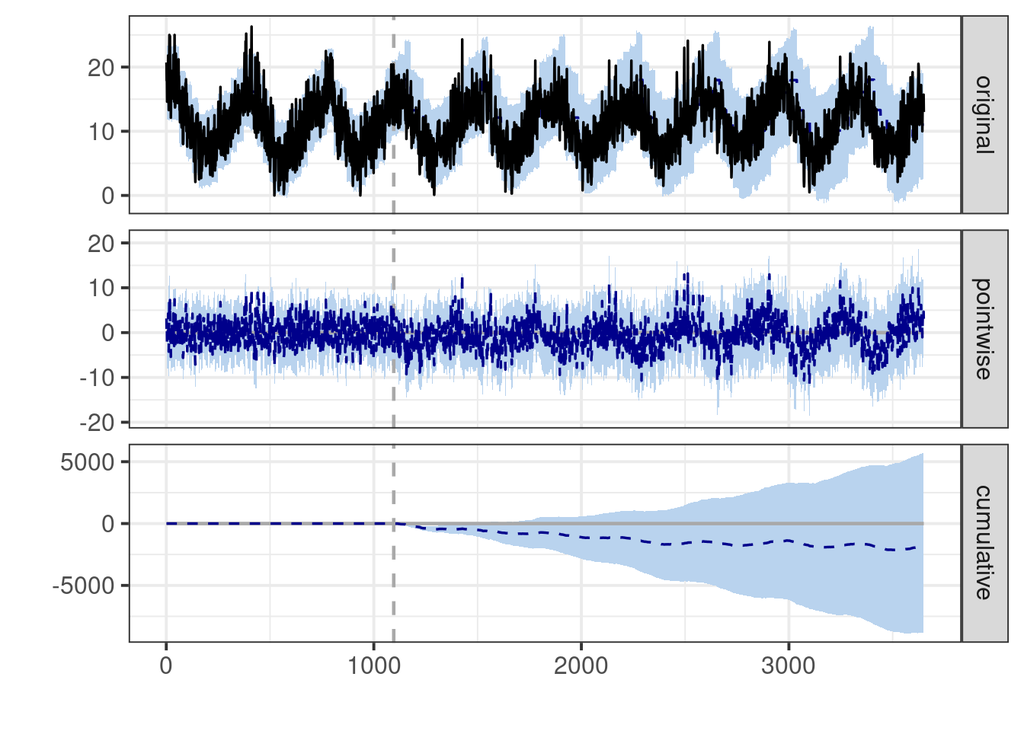

```r
impact.ll.season <- CausalImpact(data$Temp,
                                 pre.period,
                                 post.period,
                                 model.args = list(niter = 1000,
                                                   standardize.data = FALSE,
                                                   prior.level.sd = 0.01,
                                                   nseasons = 12,
                                                   season.duration = 31,
                                                   max.flips = -1
                                                   ),
                                 alpha = 0.05) # quantiles

# plot(impact.ll.season$series) # result overview
# standard causal impact plot
plot(impact.ll.season)
```

### Compare “pure bsts” and CausalImpact results

**log-likelihood…:** some differences are visible, see discussion below (autoregressive model).

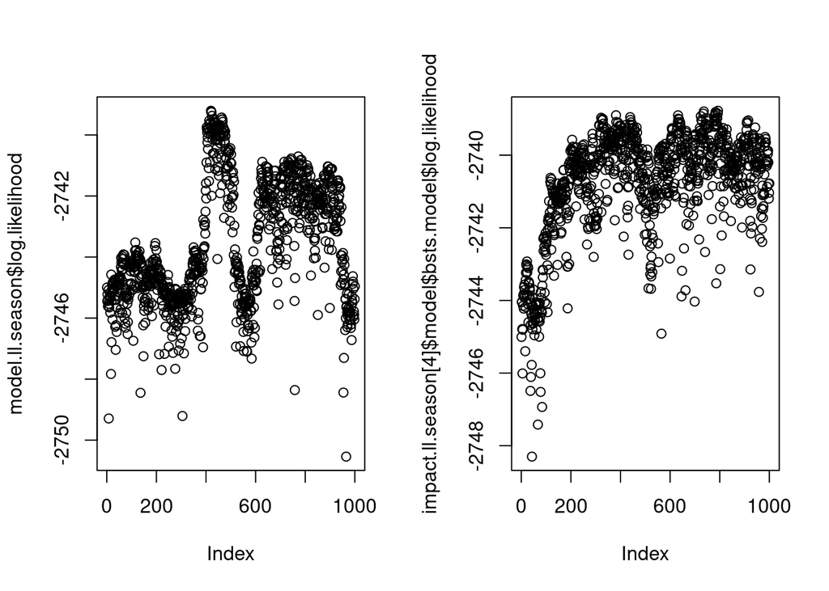

```r
par(mfrow = c(1,2))
# bsts log-likelihood
plot(model.ll.season$log.likelihood)
# CausalImpact log-likelihood
plot(impact.ll.season[4]$model$bsts.model$log.likelihood)
```

**Fitted model components…:** the plots below show the fitted components (local level and seasonality) for the bsts and the CausalImpact fit. The results are extremely similar, minor differences (especially at the first time steps) remain (the effect is more obvious for the autoregressive model, see discussion below!).

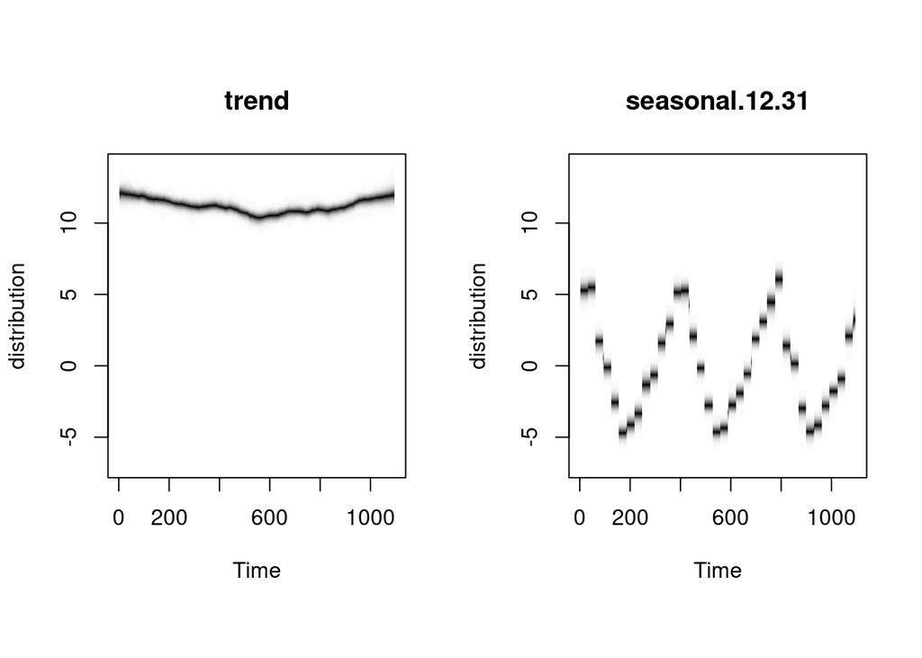

```r
# bsts components
plot(model.ll.season, "components",  xlim=c(1, pre.period[2]), ylim=c(-7, 14))
```

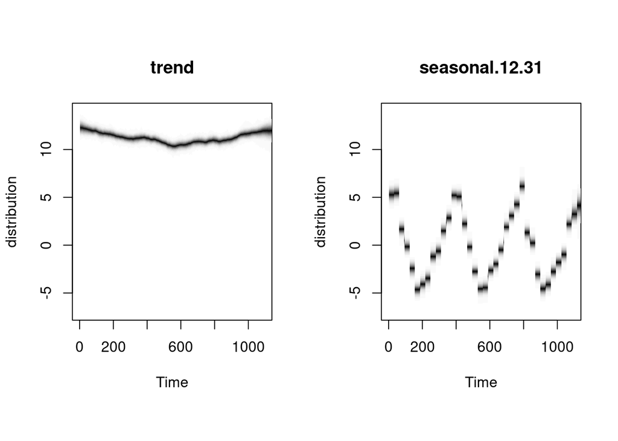

```r
# CausalImpact components
plot(impact.ll.season[4]$model$bsts.model, 'components',
     xlim=c(1, pre.period[2]), ylim=c(-7, 14))
```

```r
## pure bsts forecast
# get burn period as used in CausalImpact,
# see https://github.com/google/CausalImpact/blob/master/R/impact_inference.R
burn.period <- SuggestBurn(0.1, model.ll.season)
print(paste("burn period:", burn.period))
```

```
## [1] "burn period: 399"
```

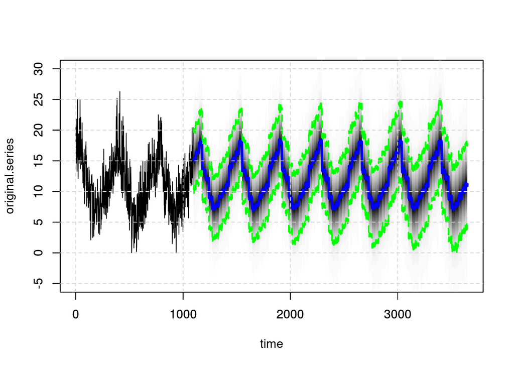

```r
# bsts prediction for post.period
# alpha (quantiles) = 0.025 (0.095) are the bsts default
pred.ll.season <- predict(model.ll.season,
                          horizon = post.period[2] - pre.period[2],
                          burn = burn.period,
                          quantiles = c(0.05, 0.95))

plot.ll.season <- plot(pred.ll.season, ylim=c(-5,30),
                       interval.quantiles = c(0.05, 0.95)) +
  grid(lty = 2)
```

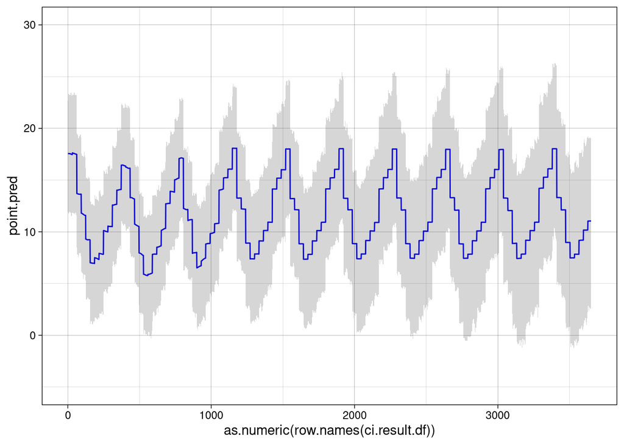

```r
## CausalImpact forecast
# convert CausalImpact results from zoo object to df for plotting
ci.result.df <- as.data.frame(impact.ll.season$series)

# ggplot of CausalImpact point prediction with confidence intervals
ci.point.pred <- ggplot(ci.result.df, aes(as.numeric(row.names(ci.result.df)),
                                          point.pred)) +
  geom_line(color='blue') +
  geom_ribbon(aes(ymin = point.pred.lower, ymax = point.pred.upper), alpha = 0.2) +
  theme_linedraw() +
  ylim(-5, 30)
ci.point.pred
```

## Fit using an autoregressive AR(1) state component and a seasonality component

In this section I fit the same data but I replace the local level component with an autoregressive component. Using an autoregressive component to capture excess noise can be more realistic if the confidence in the fit is expected to stay the same with increasing time into the future (e.g. if there is no reason for “blowing up” errors). The default model used by the CausalImpact package does not support an autoregressive model, hence feeding in a custom bsts model is necessary.

```r
# define function to fit bsts model (autoregressive and seasonal component)
# for different time series
fit.model.ar.season <- function(data2, sdy, mu.ll = zoo(1), mu.season = 0){
  # autoregressive component. SDPrior adapted from local level component in the
  # previous section
  ss.ar.season <- AddAr(list(),
                        y = data2,
                        lags = 1,
                        sigma.prior = SdPrior(sdy/100,
                                              sample.size = 32,
                                              initial.value = sdy/100,
                                              fixed = FALSE,
                                              upper.limit = sdy),
                        initial.state.prior = NormalPrior(mu = mu.ll,
                                                          sigma = sdy,
                                                          initial.value = mu.ll,
                                                          fixed = FALSE
                                                          ))
  # seasonality component ...
  ss.ar.season <- AddSeasonal(ss.ar.season,
                              y = data2,
                              sigma.prior = SdPrior(sdy/100,
                                                    sample.size = 0.01,
                                                    initial.value = sdy/100,
                                                    fixed = FALSE,
                                                    upper.limit = sdy
                                                    ),
                              initial.state.prior = NormalPrior(mu.season,
                                                                sigma = sdy,
                                                                initial.value = mu.season,
                                                                fixed = FALSE
                                                                ),
                              nseasons = 12,
                              season.duration = 31)
  # fit model ...
  model.ar.season <- bsts(data2,
                          state.specification = ss.ar.season,
                          family = c("gaussian"),
                          prior = SdPrior(sdy,
                                          sample.size = 0.01,
                                          initial.value = sdy,
                                          fixed = FALSE,
                                          upper.limit = 1.2 * sdy
                                          ),
                          niter = 1000)

  return(model.ar.season)
}

# fit bsts model on pre-period data
model.ar.season <- fit.model.ar.season(data2 = y, sdy = 4.46)
```

```
## =-=-=-=-= Iteration 0 Thu Mar 31 22:04:52 2022 =-=-=-=-=
## =-=-=-=-= Iteration 100 Thu Mar 31 22:04:53 2022 =-=-=-=-=
## =-=-=-=-= Iteration 200 Thu Mar 31 22:04:55 2022 =-=-=-=-=
## =-=-=-=-= Iteration 300 Thu Mar 31 22:04:57 2022 =-=-=-=-=
## =-=-=-=-= Iteration 400 Thu Mar 31 22:04:58 2022 =-=-=-=-=
## =-=-=-=-= Iteration 500 Thu Mar 31 22:05:00 2022 =-=-=-=-=
## =-=-=-=-= Iteration 600 Thu Mar 31 22:05:01 2022 =-=-=-=-=
## =-=-=-=-= Iteration 700 Thu Mar 31 22:05:03 2022 =-=-=-=-=
## =-=-=-=-= Iteration 800 Thu Mar 31 22:05:04 2022 =-=-=-=-=
## =-=-=-=-= Iteration 900 Thu Mar 31 22:05:06 2022 =-=-=-=-=
```

```r
# fit bsts model on pre-period data with post-period set to NA for CausalImpact
model.ar.season2 <- fit.model.ar.season(data2 = y2, sdy = 4.46)
```

```
## =-=-=-=-= Iteration 0 Thu Mar 31 22:05:08 2022 =-=-=-=-=
## =-=-=-=-= Iteration 100 Thu Mar 31 22:05:12 2022 =-=-=-=-=
## =-=-=-=-= Iteration 200 Thu Mar 31 22:05:17 2022 =-=-=-=-=
## =-=-=-=-= Iteration 300 Thu Mar 31 22:05:22 2022 =-=-=-=-=
## =-=-=-=-= Iteration 400 Thu Mar 31 22:05:26 2022 =-=-=-=-=
## =-=-=-=-= Iteration 500 Thu Mar 31 22:05:31 2022 =-=-=-=-=
## =-=-=-=-= Iteration 600 Thu Mar 31 22:05:35 2022 =-=-=-=-=
## =-=-=-=-= Iteration 700 Thu Mar 31 22:05:40 2022 =-=-=-=-=
## =-=-=-=-= Iteration 800 Thu Mar 31 22:05:45 2022 =-=-=-=-=
## =-=-=-=-= Iteration 900 Thu Mar 31 22:05:50 2022 =-=-=-=-=
```

```r
# apply CausalImpact package to custom model
impact.ar.season <- CausalImpact(bsts.model = model.ar.season2,
                                 post.period.response = post.period.response)
```

### Compare “pure bsts” and CausalImpact results

**Fitted model components:** the AR component is picking up some seasonal pattern, which will reduce the quality of the forecast as the AR component cannot forecast seasonality (side note: a “flatter” AR component can be enforced by increasing the weight of the prior… e.g. sample.size = 100 … but this leads to other unwanted behavior). Padding the training data with zeros seems to lead to minor differences between the two fits (?! not sure…), for example visible at the positions of the peaks of the seasonality component e.g. at time points ~390, ~750). These differences will also be visible in the forecasts.

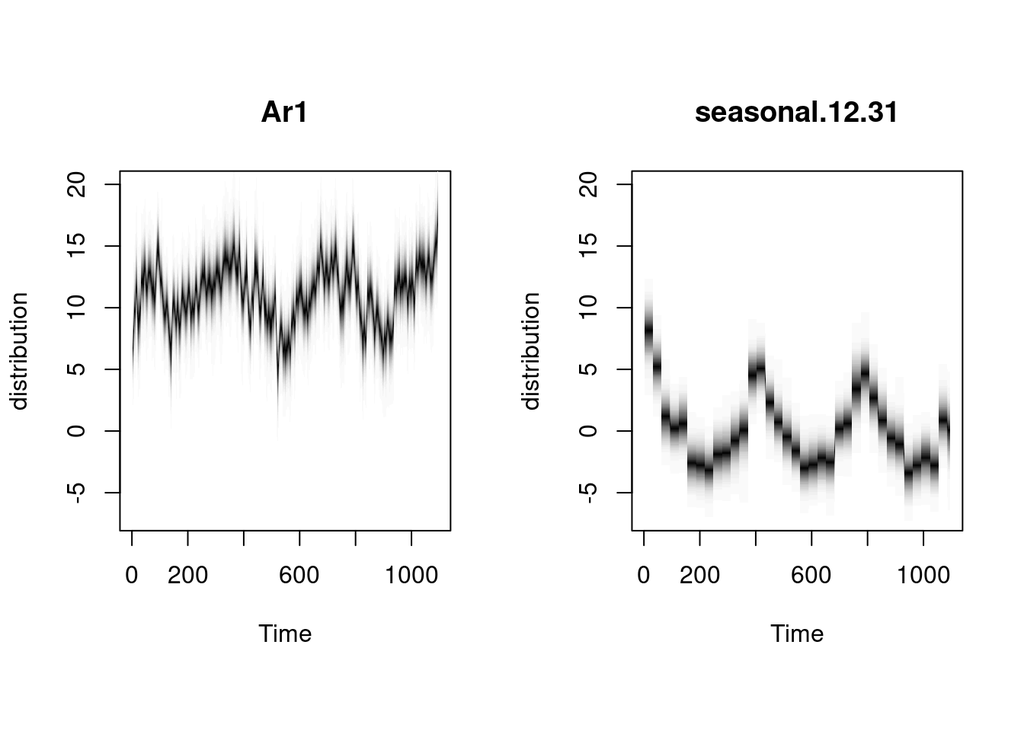

```r
# components of bsts model for time series y (without NAs)
plot(model.ar.season, "components",  xlim=c(1, pre.period[2]), ylim=c(-7, 20))
```

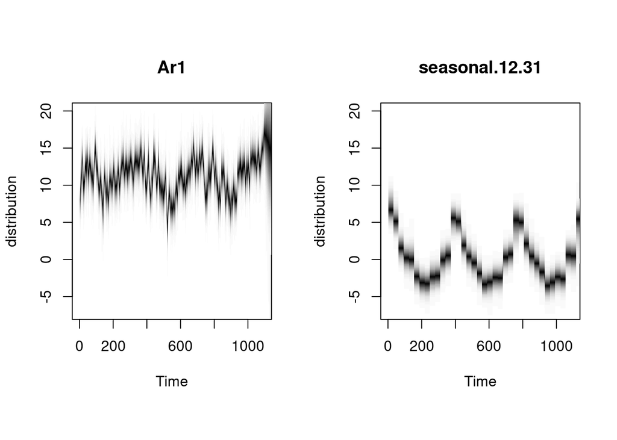

```r
# components of bsts model for time series y2 (with NAs)
plot(model.ar.season2, "components",  xlim=c(1, pre.period[2]), ylim=c(-7, 20))
```

```r
# the following code retrieves the same plot from the CausalImpact object
# plot(impact.ar.season[4]$model$bsts.model, 'components',
#      xlim=c(1, pre.period[2]), hylim=c(-7, 20))
```

**Forecasts…:** the model picked up a downwards trend from the training period that does not exist long term. As in the previous section the 31-day seasons are too long on average. In addition, the the amplitude of the forecasted pattern is too small, as some seasonality has been picked up by the autoregressive component. Therefore, the model with the local level component discussed above yields the better fit. There are some differences visible between the “pure bsts” and the CausalImpact version, especially around the annual peaks. Although minor difference could be due to numerical (random sampling) reasons, these differences seem to be due to the zero-padding (?).

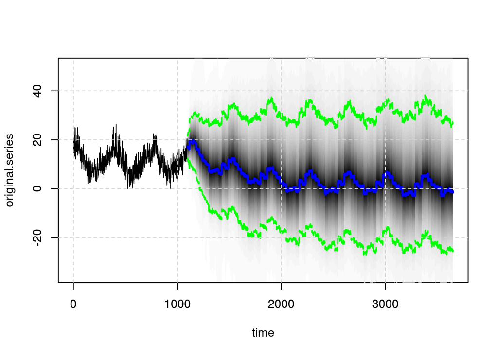

```r
# get burn period
burn.period.ar.season <- SuggestBurn(0.1, model.ar.season)
# print(paste("burn period:", burn.period.ar.season))
# bsts prediction for post.period
pred.ar.season <- predict(model.ar.season,
                          horizon = post.period[2]-pre.period[2],
                          burn = burn.period.ar.season,
                          quantiles = c(0.05, 0.95))

bsts.forcast.ar.season <- plot(pred.ar.season, ylim=c(-35,50),
                               interval.quantiles = c(0.05, 0.95)) +
  grid(lty = 2)
```

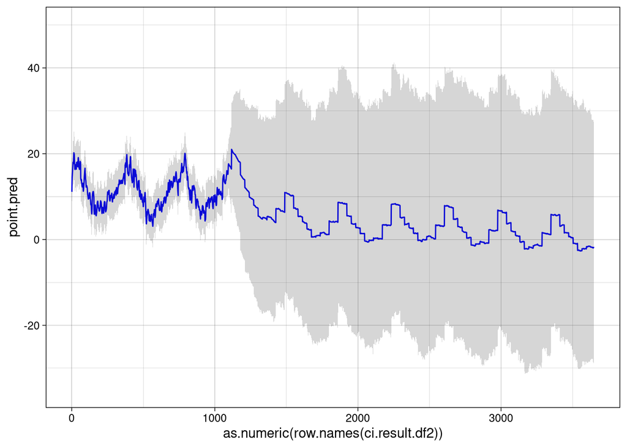

```r
# convert CausalImpact results from zoo object to df for plotting
ci.result.df2 <- as.data.frame(impact.ar.season$series)
# ci.result.df

# ggplot if CausalImpact point prediction with confidence intervals
ci.point.pred2 <- ggplot(ci.result.df2, aes(as.numeric(row.names(ci.result.df2)),
                                          point.pred)) +
  geom_line(color='blue') +
  geom_ribbon(aes(ymin = point.pred.lower, ymax = point.pred.upper), alpha = 0.2) +
  theme_linedraw() +
  ylim(-35, 50)
ci.point.pred2
```

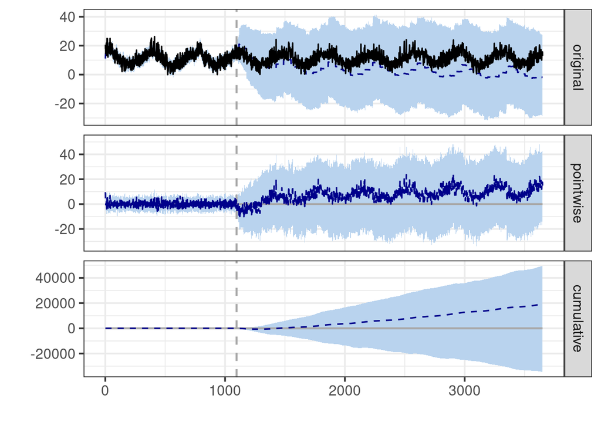

```r
plot(impact.ar.season)
```

### Additional remark: analysis of selected fitted standard deviations and coefficients

As one can also see in the fitted components / forecasts, the variability of the AR components is a lot higher than the variability of the local level component. Note that the fitted AR1 coefficient is very close to 1, hence the two models are quite similar.

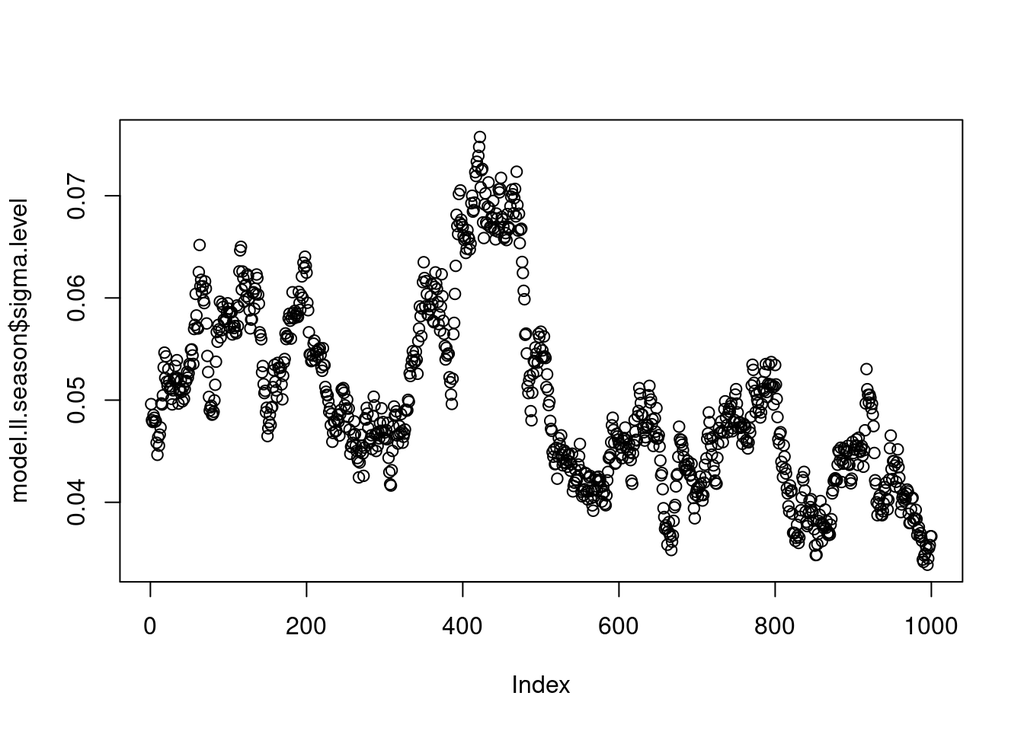

```r
# standard deviation of the local level component
plot(model.ll.season$sigma.level)
```

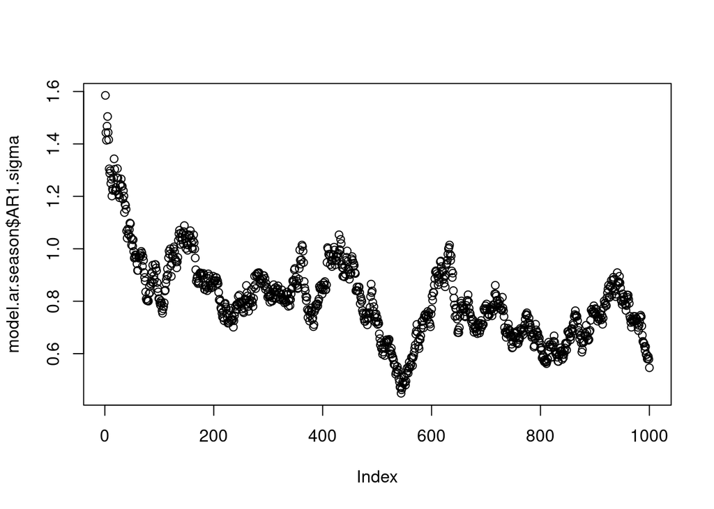

```r
# standard deviation of the autoregessive component
plot(model.ar.season$AR1.sigma)
```

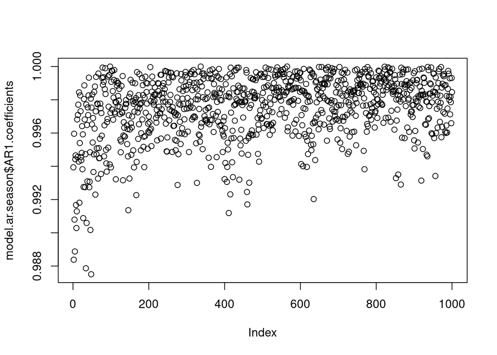

```r
# fitted AR1 component
plot(model.ar.season$AR1.coefficients)
```

## References and learning resources

- Data set: https://machinelearningmastery.com/time-series-datasets-for-machine-learning/
- bsts R package: https://CRAN.R-project.org/package=bsts by Steven L. Scott
- CausalImpact R package: CausalImpact 1.2.1, Brodersen et al., Annals of Applied Statistics (2015), http://google.github.io/CausalImpact/
- bsts tutorial I found helpful: https://www.unofficialgoogledatascience.com/2017/07/fitting-bayesian-structural-time-series.html